# Projekt statystyka

Jakub Sus  
Jeremiasz Śliwiński

## Użyte algorytmy

### 1. GA

Algortym Genetyczny z biblioteki GA. Na start wybierane jest p punktów (gdzie p jest polulacją). Następnie powtarzamy podane kroki: - wyliczamy fitness score z populacji - wybieramy osobników o największym fitness score, i dodajemy ich do populacji następnej ery - krzyżujemy oraz mutujemy pozostałych osobników

### 2. PRS

Poszukiwanie przypadkowe, polegające na wybierniu minimum z określonej ilościu losowo wybranych punktów z rozkładem jednostajnym w zadanej dziedzinie.

Ilość wywołań minimalizowanej funkcji w alrogytmie GA nie jest stała, z tego powodu, PRS wywoływany jest z budżetem równym średniej liczbie wywołań GA

## Funkcje użyte w porównaniu

#### 1.Ackley

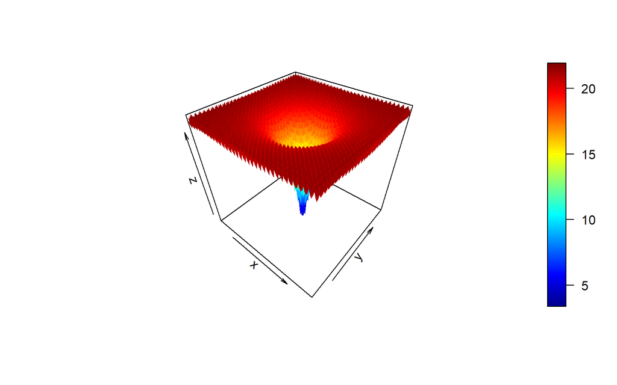

Global minimum: 0

#### 2.Rosenbrock

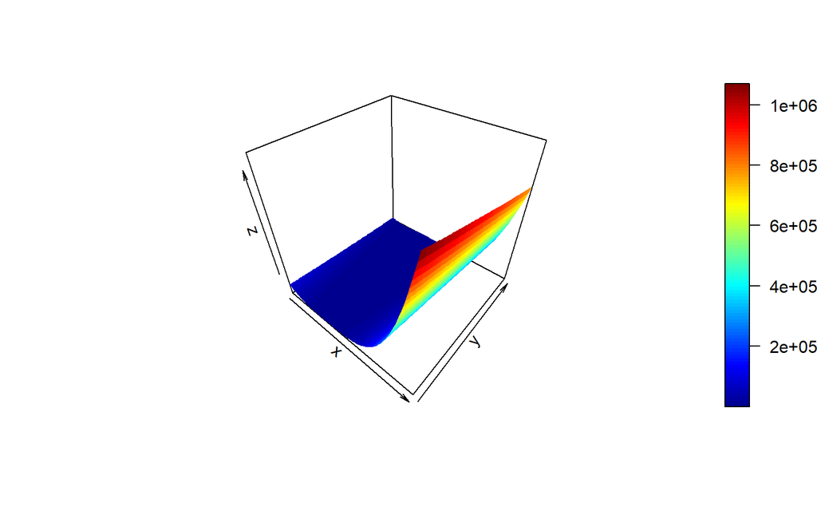

Global minimum: 0